# Sampling Plans Presentation

Boning Liu

# Introduction

Analysis, We carry out an analysis by comparing the performance of three random sampling plans: simple random sampling (SRS), systematic sampling (SS), and stratified sampling based on a large bank load data set as the finite population.

The original data set was split into 9 subsets that are stored on GitHub. We need to load these data sets to R and create a single data set.

# Three Sampling Plans- A Review

In this analysis, we will use three different sampling plans: simple random sampling (SRS), systematic sampling, and stratified sampling.

# Simple Random Sampling

A simple random sample takes a small, random portion of the entire population to represent the entire data set, where each member has an equal probability of being chosen.

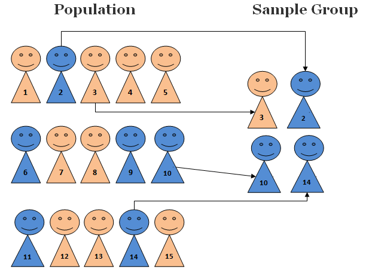

# Systematic Sampling

Systematic sampling is a probability sampling method in which a random sample, with a fixed periodic interval (jump size), is selected from a larger population.

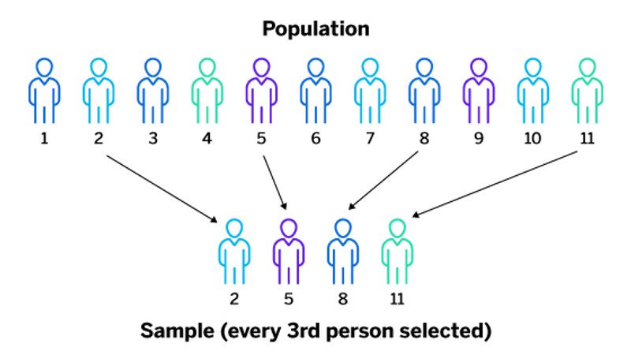

# Stratified Sampling

Stratified sampling involves the division of a population into smaller subgroups known as strata. In stratified, the strata are formed based on members’ shared attributes or characteristics, such as income or educational attainment. The shared attribute or characteristic is known as the stratification variable.

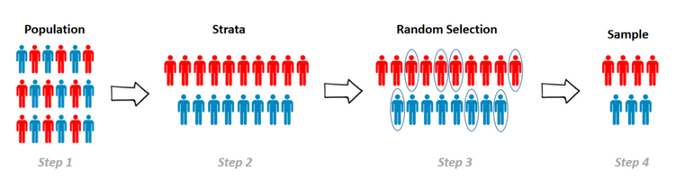

## Stratification Variable

For my stratification variable, I choose to use the term BankState.

| Population.size | Number.of.Bank.States | Sub.Pop.less.900 |
| --- | --- | --- |
| 899164 | 57 | 5 |

Next, we explore the frequency distribution of the 2-digit BankState.

|  | AK | AL | AN | AR | AZ | CA | CO | CT | DC | DE | EN | FL | GA | GU | HI | IA | ID | IL | IN | KS | KY | LA | MA | MD | ME | MI | MN | MO | MS | … |
| --- | --- | --- | --- | --- | --- | --- | --- | --- | --- | --- | --- | --- | --- | --- | --- | --- | --- | --- | --- | --- | --- | --- | --- | --- | --- | --- | --- | --- | --- | --- |
| 1566 | 1439 | 12134 | 1 | 6322 | 3957 | 118116 | 10582 | 9917 | 4003 | 24537 | 1 | 13810 | 13812 | 5 | 2991 | 9866 | 4314 | 65908 | 7623 | 8876 | 4382 | 5062 | 13913 | 7016 | 3691 | 7369 | 19960 | 14861 | 5942 | … |

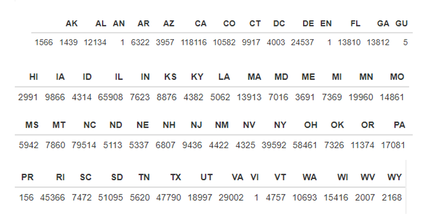

Here, I combine the bank states that are from HI to PA.

## Study Population

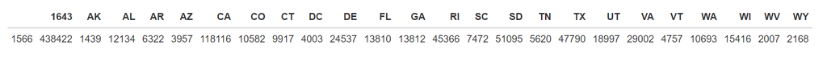

Note: 1643 is the combined states from HI to PA (HI being the 16th and PA being the 43rd in categories)

## Loan Default Rates by Bank States: Study Population

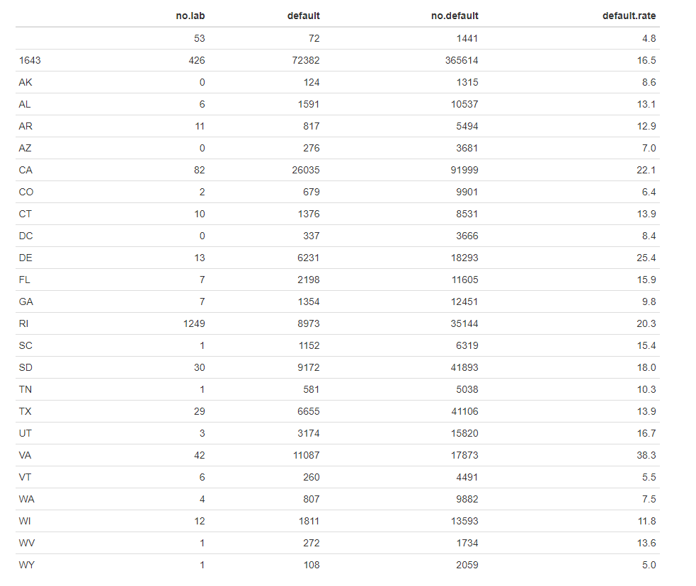

- **Simple Random Sampling**

We simply take random IDs and then identify the records based on the sampled IDs to obtain the SRS sample.

- **Systematic sampling**

- **Stratified Sampling**

We take an SRS from each stratum. The sample size should be approximately proportional to the size of the corresponding stratum. First, we calculate the SRS size for each stratum and then take the SRS from the corresponding stratum. Then take SRS samples from the corresponding subpopulations.

# Performance Analysis of Random Samples

Comparison of Bank State-specific default rates between population, SRS, Systematic Sample, and Stratified Samples.

|  | default.rate.pop | default.rate.srs | default.rate.sys | default.rate.str |
| --- | --- | --- | --- | --- |
| AL | 13.1 | 12.0 | 7.7 | 24.1 |
| AR | 12.9 | 3.8 | 13.5 | 7.1 |
| AZ | 7.0 | 15.4 | 5.9 | 11.1 |
| CA | 22.1 | 21.9 | 20.7 | 23.8 |
| CO | 6.4 | 3.7 | 11.4 | 10.6 |
| CT | 13.9 | 7.9 | 17.5 | 11.4 |
| DC | 8.4 | 12.5 | 9.1 | 0.0 |
| DE | 25.4 | 23.3 | 21.7 | 19.3 |
| FL | 15.9 | 1.9 | 15.0 | 14.8 |
| GA | 9.8 | 11.5 | 12.9 | 13.1 |
| RI | 20.3 | 20.2 | 22.7 | 19.0 |
| SC | 15.4 | 21.9 | 5.4 | 18.2 |
| SD | 18.0 | 17.2 | 16.9 | 19.4 |
| TN | 10.3 | 5.6 | 4.2 | 4.0 |
| TX | 13.9 | 9.6 | 11.3 | 15.5 |
| UT | 16.7 | 24.7 | 14.4 | 23.5 |
| VA | 38.3 | 37.5 | 41.0 | 45.0 |
| VT | 5.5 | 5.0 | 0.0 | 9.5 |
| WA | 7.5 | 1.8 | 5.1 | 6.2 |
| WI | 11.8 | 10.4 | 11.7 | 13.0 |
| WV | 13.6 | 16.7 | 12.5 | 11.1 |
| WY | 5.0 | 0.0 | 7.7 | 0.0 |

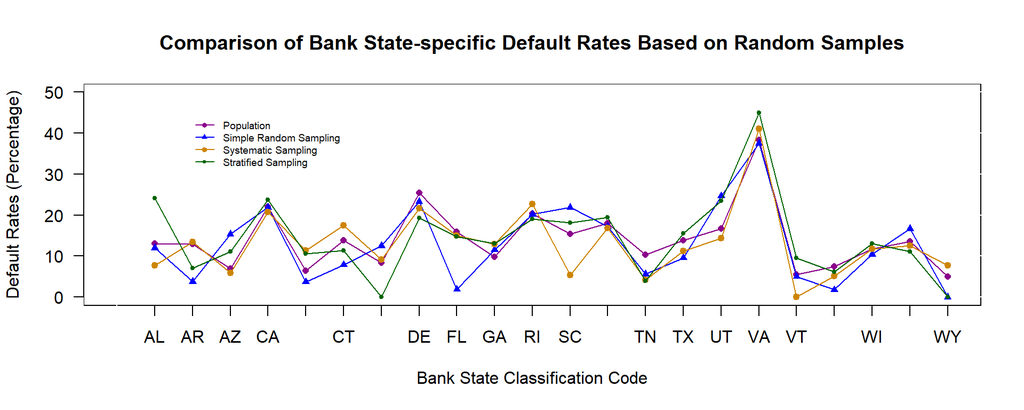

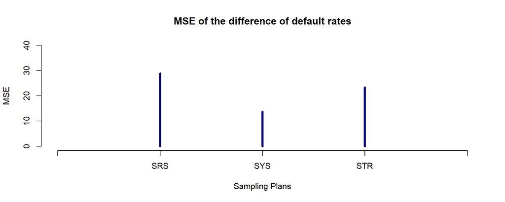

# Conclusion

The MSE values are different for the three sampling plans each time we take sample.In order to make the approach more reliable it is better to take multiple samples and compare the mean of the MSEs.